# Day Care Fines

## Background

Will implementing a fine change how people view their obligations? A number of parents have been consistently late in picking up their children from day-care centers in Israel. A study was performed to see what would happen if a fine was introduced. Details on the study are shown in the links below.

Details of the Day Care Study (click to view)

The Data: Wide Format (click to view)

The Data: Long Format (click to view)

### Questions and Hypotheses

The significance level will be set at

$$\alpha = 0.05$$
Since a Two-Way ANOVA test will be performed, there will not be three separate distributions of the significance level.

Question 1 (click to view)

Question 2 (click to view)

Question 3 (click to view)

## Analysis

The Two-Way ANOVA is performed by using this model.

$$Y_{ijk} = \mu + \alpha_i + \beta_j + \alpha\beta_{ij} + \epsilon_{ijk}$$
$\mu$ is the grand mean

$\alpha_i$ is the Treatment factor with levels $C=1$ and $F=2$

$\beta_j$ is the Period factor with levels $B=1$, $D=2$, and $A=3$

$\alpha\beta_{ij}$ is the interaction of the two factors which has $2\times3=6$ levels

$\epsilon_{ijk} \sim N(0,\sigma^2)$ is the error term.

```r
Late <- read.csv("../Data/Late.csv", header=TRUE)
Late$Period <- mapvalues(Late$Week, 1:20,c(rep("Before", 4), rep("During", 12), rep("After", 4)))
Late.aov <- aov(No.ofLateChildren ~ Period + Treatment + Period:Treatment, data=Late)
pander(summary(Late.aov))
```

Analysis of Variance Model

|  | Df | Sum Sq | Mean Sq | F value | Pr(>F) |
| --- | --- | --- | --- | --- | --- |
| **Period** | 2 | 828 | 414 | 12.91 | 5.456e-06 |
| **Treatment** | 1 | 1740 | 1740 | 54.25 | 4.925e-12 |
| **Period:Treatment** | 2 | 847.7 | 423.9 | 13.22 | 4.162e-06 |
| **Residuals** | 194 | 6222 | 32.07 | NA | NA |

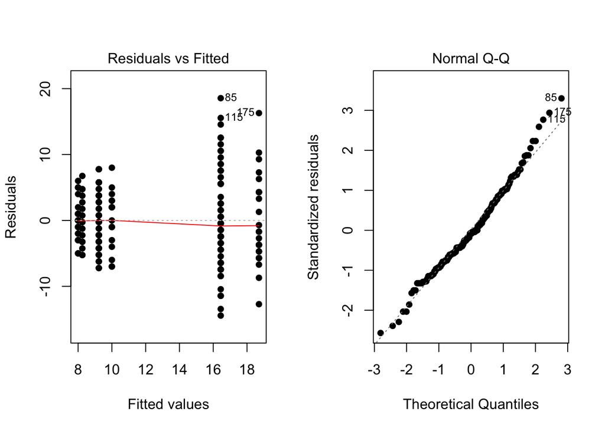

```r
par(mfrow=c(1,2))
plot(Late.aov, which=1:2, pch=16)
```

### Requirements for the Tests

On the left, the residual plot demonstrates the constant variances for each group are somewhat questionable because the spread of the vertical data sets is becoming larger as the fitted values increase. On the right, the QQ plot shows the errors are normally distributed because the points follow an approximately straight line. Even though the change in variance is questionable, the spread is not large enough to be revoked for the Two-Way ANOVA Test. The validity of the tests is sufficient.

### Results of the Tests

Question 1 (click to view)

Question 2 (click to view)

Question 3 (click to view)

## Graphical Summary

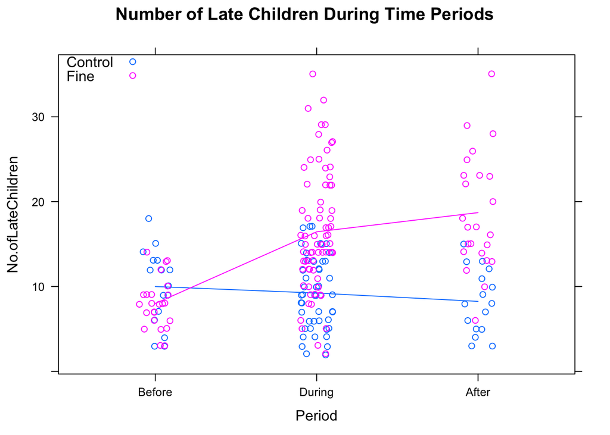

```r
Late$Period <- factor (Late$Period, levels = c("Before", "During", "After"))

xyplot( No.ofLateChildren ~ Period, data = Late, groups=Treatment, main="Number of Late Children During Time Periods", jitter.x=TRUE, jitter.y=TRUE, type=c("p", "a"), auto.key=list(corner=c(0,1)))
```

## Interpretation

Question 1 (click to view)

Question 2 (click to view)

Question 3 (click to view)

**Conclusion**

There is a relationship between Treatment and Period. As the Period time increased there was a remarkable difference in the number of children who were late in the Fine group in comparison to the baseline, Control group.

Interestingly enough, after the fine was withdrawn, the number of late children did not decrease. Instead, the number actually slightly increased. Did the fine change how these parents viewed their obligations? Maybe the parents felt it was okay to be late to pick up their children when they were paying a fine.

A further study could be performed over a longer period of time to focus on the behavior of people taking advantage of a priviledge, then have it withdrawn for a time, then to receive the priviledge again to measure their behaviors to see if the results are consistent with the results from this study.